# ANOVA: Analysis of Variance

Erin M. Buchanan

Last Updated: 2021-02-07

# Comparing Means

- In the last section, we covered how to compare two means with t-tests.
- However, you can only compare two means at a time with t-tests.
- Further, you can only have one predictor variable - that’s the two groups/measurements.

# Analysis of Variance: ANOVA

- Compares several means at the same time.
- Can be used when you have more than one independent variable
- ANOVA is also a special form of regression, often called the general linear model.

# Why not use t-Tests?

- If we want to compare three or more means why don’t we compare pairs of means with t-tests?
  - Cannot examine several independent variables.
  - Inflates the Type I error rate.

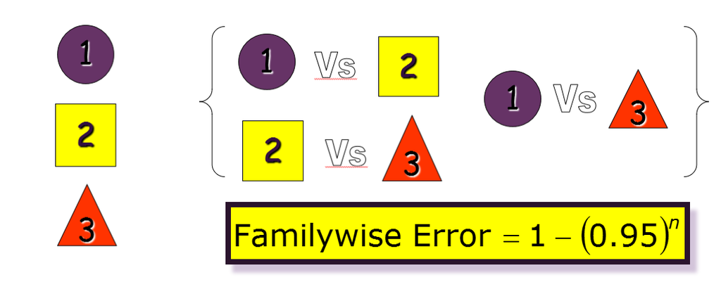

# Type I Error

- Formula = $1 - (1-\alpha)^c$
  - Alpha = type I error rate = .05 usually *(that’s why the last slide had .95)*
  - C = number of comparisons
- Therefore, if you have:
  - Three groups - three comparisons = 0.143
  - Four groups - six comparisons = 0.265
  - Five groups - ten comparisons = 0.401

# Regression v ANOVA

- ANOVA in Regression:
  - Used to assess whether the regression model is good at predicting an outcome.
- ANOVA in Experiments:
  - Used to see whether experimental manipulations lead to differences in performance on an outcome (DV).
  - By manipulating a predictor variable can we cause (and therefore predict) a change in behavior?
- Actually can be the same question!

# ANOVA: Understanding the NHST

- H0: There are no differences in means.
- H1: There are differences in the means.
- ANOVA is an Omnibus test
  - It test for an overall difference between groups.
  - It tells us that the group means are different.
  - It doesn’t tell us exactly which means differ.

# ANOVA: Understanding the NHST

- We compare the amount of variability explained by the Model *(experiment)*, to the error in the model *(individual differences)*
- This ratio is called the F-ratio.
- If the model explains a lot more variability than it can’t explain, then the experimental manipulation has had a significant effect on the outcome *(DV)*.

# ANOVA: F-ratio

- Variance created by our manipulation *(IV levels)*
  - Good variance *(systematic variance)*
- Variance created by unknown factors
  - Bad variance *(unsystematic variance)*

# ANOVA: F-ratio

- We calculate how much variability there is between scores: total sum of squares $SS_T$. This value is then divided into:
  - We then calculate how much of this variability can be explained by the model we fit to the data: model sum of squares $SS_M$
  - How much cannot be explained: residual sum of squares $SS_R$
- If the experiment is successful, then the model will explain more variance than it can’t after accounting for differences in group sizes in these calculations

# ANOVA: Example

- Testing the effects of Viagra on Libido using three groups:
  - Placebo (Sugar Pill)
  - Low Dose Viagra
  - High Dose Viagra
- The Outcome/Dependent Variable (DV) was an objective measure of Libido.

# The Data

```r
library(rio)
master <- import("data/viagra.sav")
str(master)
```

```
## 'data.frame':    15 obs. of  3 variables:
##  $ person: num  1 2 3 4 5 6 7 8 9 10 ...
##   ..- attr(*, "label")= chr "Participant"
##   ..- attr(*, "format.spss")= chr "F8.0"
##  $ dose  : num  1 1 1 1 1 2 2 2 2 2 ...
##   ..- attr(*, "label")= chr "Dose of Viagra"
##   ..- attr(*, "format.spss")= chr "F8.0"
##   ..- attr(*, "labels")= Named num [1:3] 1 2 3
##   .. ..- attr(*, "names")= chr [1:3] "Placebo" "Low Dose" "High Dose"
##  $ libido: num  3 2 1 1 4 5 2 4 2 3 ...
##   ..- attr(*, "label")= chr "Libido"
##   ..- attr(*, "format.spss")= chr "F8.0"
```

```r
master$dose <- factor(master$dose,
                      levels = c(1,2,3),
                      labels = c("Placebo", "Low Dose", "High Dose"))
```

# Calculate $SS_T$

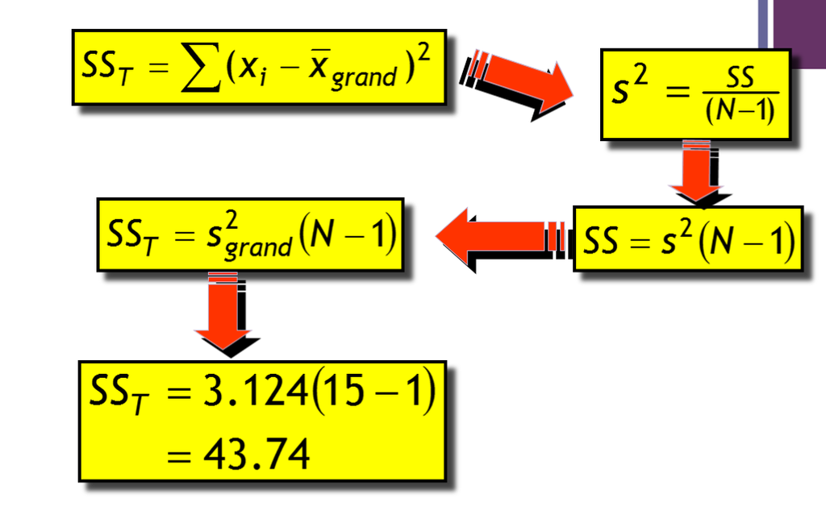

# Visualize $SS_T$:

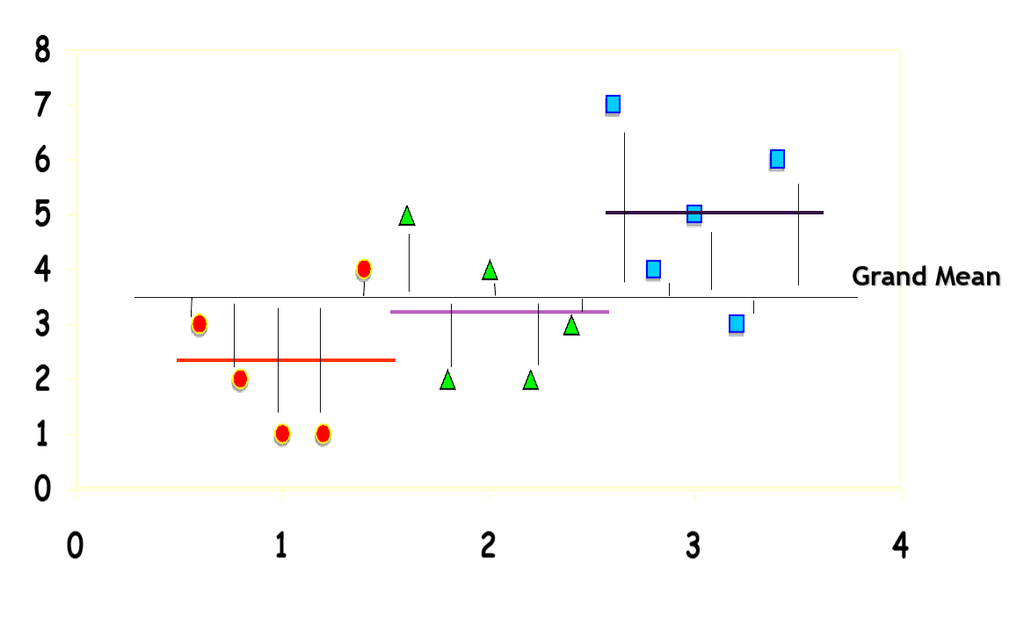

# $SS_T$ df

- Degrees of Freedom (df) are the number of values that are free to vary.
- In general, the df are one less than the number of values used to calculate the SS.
  - $df_T$ = (N-1) = 15-1 = 14

# Calculate $SS_M$

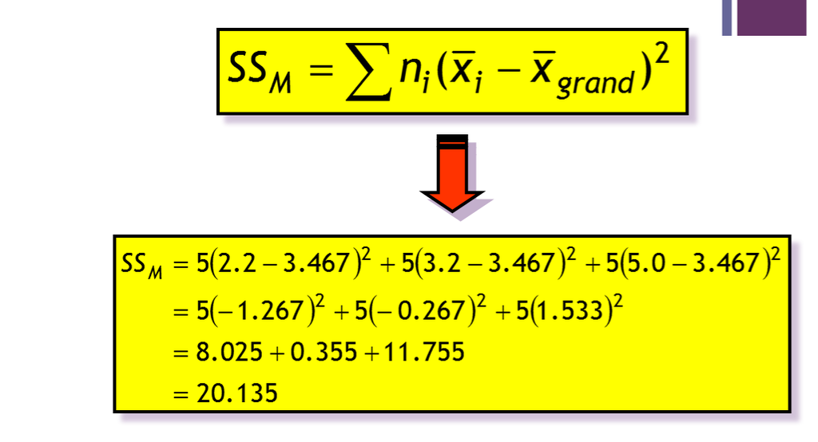

# Visualize $SS_M$

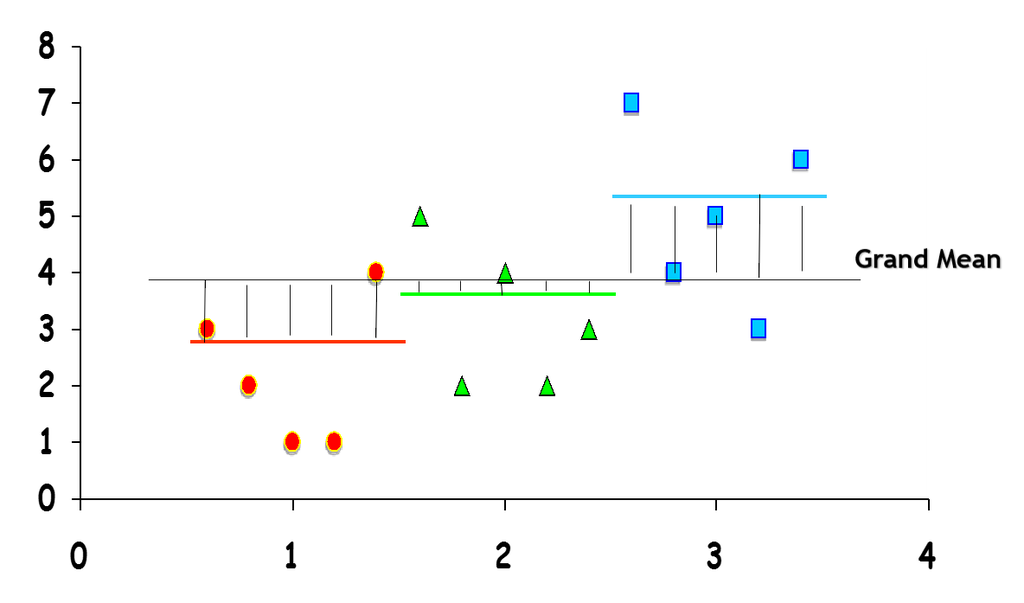

# $SS_M$ df

- How many values did we use to calculate $SS_M$?
  - We used the 3 means (levels).
  - $df_M$ = (k-1) = 3-1 = 2

# Calculate $SS_R$

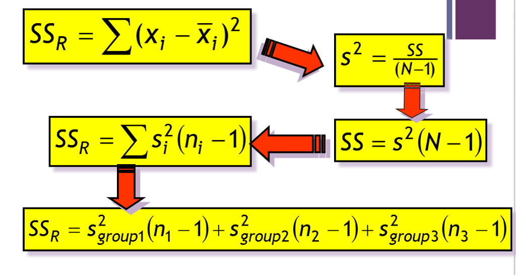

# Visualize $SS_R$

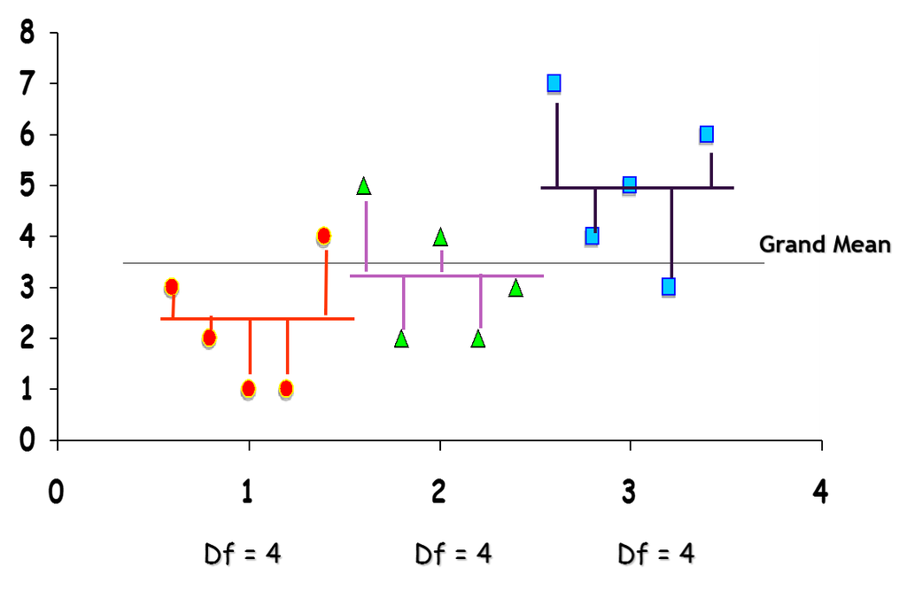

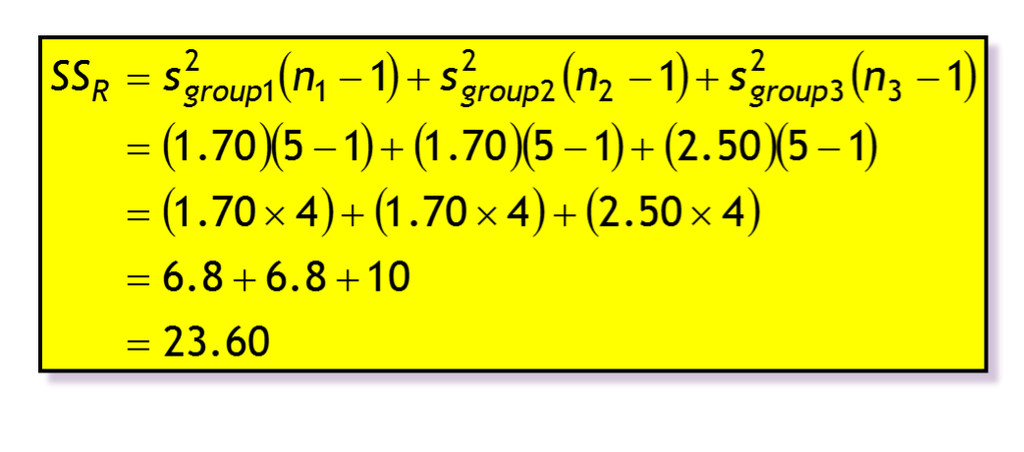

# $SS_R$ df

- How many values did we use to calculate $SS_R$?
  - We used the 5 scores for each of the SS for each group.

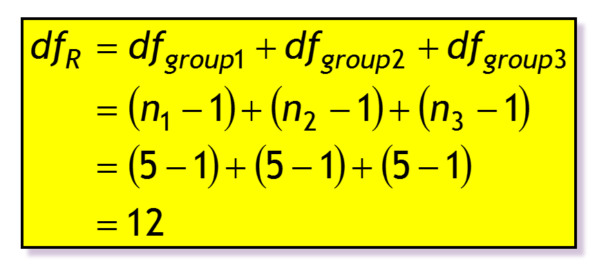

# Double Check

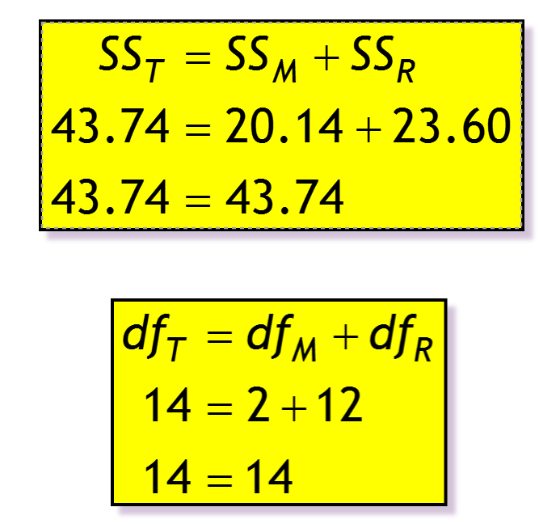

# Calculate Mean Squared Error

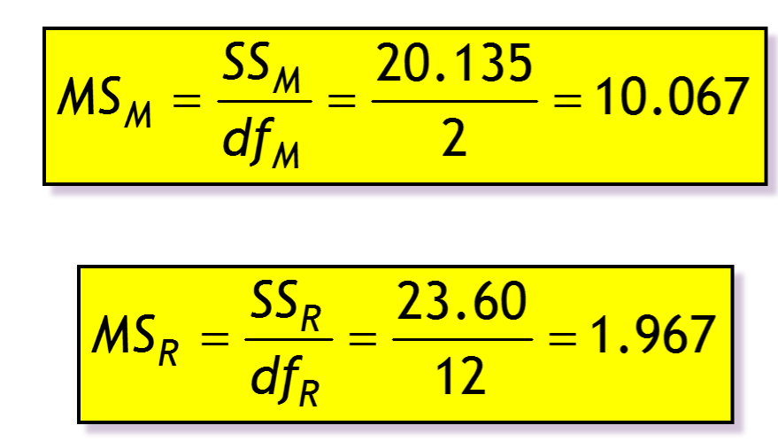

# Calculate the F-Ratio

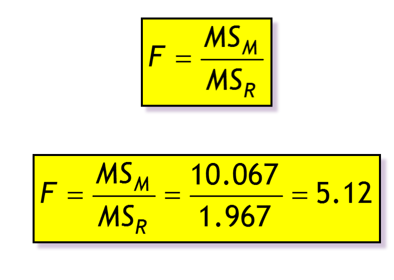

# Construct a Summary Table

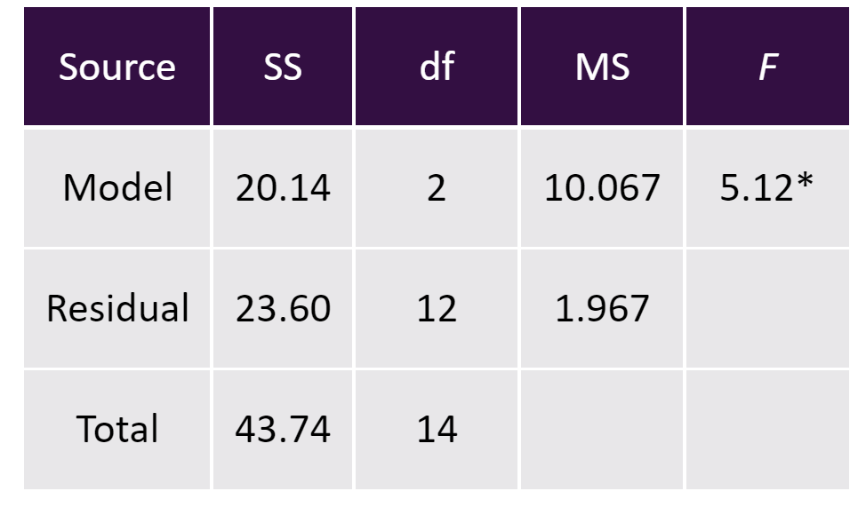

# F-values

- Since all these formulas are based on variances, the *F*-statistic is never negative.
- Think about the logic of model divided by error:
  - If your values are small you are saying model = error = just a bunch of noise because people are different
  - If your values are large then model > error, which means you are finding an effect.

# Assumptions

- Data screening: accuracy, missing, outliers
- Normality
- Linearity *(it is called the general linear model!)*
- Homogeneity - Levene’s *(new!)*
- Homoscedasticity *(still a form of regression)*
- **Note:** You can do the normal screening we’ve already done and add Levene’s test.

# Assumptions

- ANOVA is often called a “robust test”
- Robustness is the ability to still give you accurate results even though the assumptions are not quite met.
  - Tests are robust with equal sample sizes in groups
  - When sample sizes are sufficiently large

# Assumptions

- Levene’s Test
  - Levene’s test is an ANOVA using variances as a testing point, instead of the means.
  - Tells you if variances are equal across groups.
  - You DO NOT want this test to be significant, and remember our data screening $\alpha$, p < .001 is bad.

# ANOVA: Analysis

- We are going to use the `ezANOVA` function in the `ez` library. This package can analyze many types of ANOVA, run the assumption tests, and give you effect size all at once.
- First, you must add a participant number if you do not already have one in the dataset.
  - It is advantageous to wait to add one until the end of data screening (or you would need to drop that column for every assumption test).
  - Also make sure the IV is factored, or it will not give you Levene’s test.

# ANOVA: Analysis

- You will get a warning - just ignore it: “Warning converting partno to a factor for ANOVA”.

```r
library(ez)
## you must have a participant number for ezANOVA
master$partno <- 1:nrow(master)
options(scipen = 20)
ezANOVA(data = master,
        dv = libido,
        between = dose,
        wid = partno,
        type = 3,
        detailed = T)
```

```
## Warning: Converting "partno" to factor for ANOVA.
```

```
## Coefficient covariances computed by hccm()
```

```
## $ANOVA
##        Effect DFn DFd       SSn  SSd         F               p p<.05       ges
## 1 (Intercept)   1  12 180.26667 23.6 91.661017 0.0000005720565     * 0.8842381
## 2        dose   2  12  20.13333 23.6  5.118644 0.0246942895382     * 0.4603659
##
## $`Levene's Test for Homogeneity of Variance`
##   DFn DFd       SSn SSd         F         p p<.05
## 1   2  12 0.1333333 6.8 0.1176471 0.8900225
```

# ANOVA: Levene’s

- Levene’s test is not significant, $F(2,12) = 0.12, p = .890$

```r
ezANOVA(data = master,
        dv = libido,
        between = dose,
        wid = partno,
        type = 3,
        detailed = T)$`Levene's Test for Homogeneity of Variance`
```

```
##   DFn DFd       SSn SSd         F         p p<.05
## 1   2  12 0.1333333 6.8 0.1176471 0.8900225
```

# ANOVA: Levene’s

- What do you do if homogeneity test was significant? *(Levene’s)*
- Run a Welch correction on the ANOVA using the oneway function.

```r
## running a one way anova - if Levene's Test is significant
oneway.test(libido ~ dose, data = master)
```

```
##
##  One-way analysis of means (not assuming equal variances)
##
## data:  libido and dose
## F = 4.3205, num df = 2.0000, denom df = 7.9434, p-value = 0.05374
```

# ANOVA: F-Statistic

- There was a significant effect of Viagra on levels of libido, $F(2, 12) = 5.12, p = .025, \eta^2= .46$

```
##        Effect DFn DFd       SSn  SSd         F               p p<.05       ges
## 1 (Intercept)   1  12 180.26667 23.6 91.661017 0.0000005720565     * 0.8842381
## 2        dose   2  12  20.13333 23.6  5.118644 0.0246942895382     * 0.4603659
```

# ANOVA: Effect Size

- In ANOVA, there are two effect sizes - one for the overall *(omnibus)* test and one for the follow up tests *(coming next)*.
- F-test
  - $R^2$ or $\eta^2$ or $ges^2$
  - $\omega^2$

# ANOVA: Effect Size

- Proportion of variability accounted for by an effect
- Useful when you have more than two means, gives you the total good variance with 3+ means
- Can only be positive
- Range from .00 - 1.00
- Small = .01, medium = .06, large = .15

# ANOVA: Effect Size

- $R^2$ - more traditionally listed with regression
- $\eta^2$ - more traditionally listed with ANOVA
- $ges^2$ - a newer effect size suggested to correct for ANOVA overestimation
- These are all equal in a one-way between subjects ANOVA
- $\frac{SS_M}{SS_T}$

# ANOVA: Effect Size

- $\omega^2$ is a suggested correction for the overestimation of the other statistics
- Omega squared is an $R^2$ style effect size *(variance accounted for)* that estimates effect size on population parameters
- $\frac{SS_M - df_M \times MS_R}{SS_T + MS_R}$

```r
library(MOTE)
effect <- omega.F(dfm = 2, #this is dfn in the anova
                  dfe = 12, #this is dfd in the anova
                  Fvalue = 5.12, #this is F
                  n = 15, #look at the number of rows in your dataset
                  a = .05) #leave this as .05
effect$omega
```

```
## [1] 0.3545611
```

# Post Hocs and Trends: Why Use Follow-Up Tests?

- The F-ratio tells us only that the experiment was successful, and group means were different.
- It does not tell us specifically which group means differ from which.
- We need additional tests to find out where the group differences lie.

# Post Hocs and Trends: How?

- Multiple t-tests
  - We saw earlier that this path is a bad idea for type I error
- Orthogonal Contrasts/Comparisons
  - Hypothesis driven
  - Planned a priori
- Post Hoc Tests
  - Not Planned (a posteriori)
  - Compare all pairs of means
  - But this is just a bunch of t-tests, so we have to correct for type I error issues
- Trend Analysis

# Post Hoc Tests

- Compare each mean against all others.
- In general terms they use a stricter criterion to accept an effect as significant.
- TEST = t.test or F.test
- CORRECTION = None, Bonferroni(*), Tukey, SNK, Scheffe

# Post Hoc Tests

- For all of these post hocs, we are going to use t-test to calculate the if the differences between means is significant.
- We are going to run the Bonferroni and compare to no correction to talk about how these corrections work.

# Post Hoc Tests: Bonferroni

- Restricted sets of contrasts - these tests are better with smaller families of hypotheses *(i.e. less comparisons)*.
- These tests adjust the required *p* value needed for significance.
- Bonferroni - the overall $\alpha$ error rate is related to the number of comparisons
- Therefore, it’s easy to correct for the problem by dividing alpha by c to control where the new $\alpha$ = $\frac{\alpha}{c}$
- The output you see has corrected the *p* value to account for this new $\alpha$, so you can remember your old cut off score.
- Other types of restricted contrasts:
  - Sidak-Bonferroni
  - Holm
  - Dunnett’s test

# Post Hoc Tests: Comparison

```r
## post hoc tests - p.value adjustment "none"
pairwise.t.test(master$libido,
                master$dose,
                p.adjust.method = "none",
                paired = F,
                var.equal = T)
```

```
##
##  Pairwise comparisons using t tests with pooled SD
##
## data:  master$libido and master$dose
##
##           Placebo Low Dose
## Low Dose  0.2816  -
## High Dose 0.0083  0.0652
##
## P value adjustment method: none
```

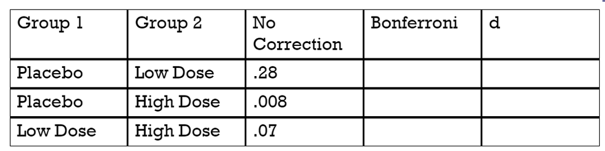

# Post Hoc Tests: Bonferroni

```r
## post hoc tests - p.value adjustment "bonferroni"
pairwise.t.test(master$libido,
                master$dose,
                p.adjust.method = "bonferroni",
                paired = F,
                var.equal = T)
```

```
##
##  Pairwise comparisons using t tests with pooled SD
##
## data:  master$libido and master$dose
##
##           Placebo Low Dose
## Low Dose  0.845   -
## High Dose 0.025   0.196
##
## P value adjustment method: bonferroni
```

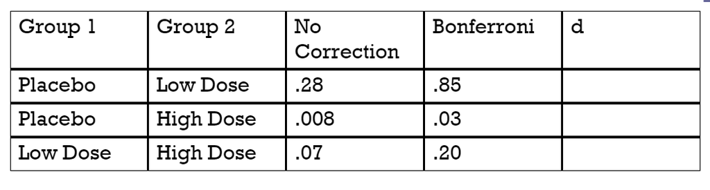

# Post Hoc Tests: Effect Size

- Because we have calculated every pairwise combination, we can use $d_s$ to calculate the effect sizes for each combination.

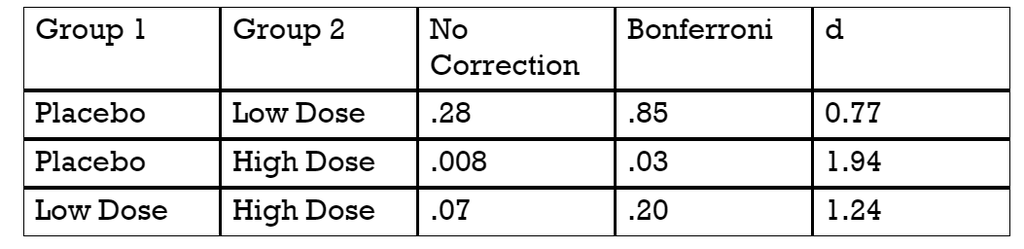

```r
## get numbers for effect size
M <- tapply(master$libido, master$dose, mean)
N <- tapply(master$libido, master$dose, length)
STDEV <- tapply(master$libido, master$dose, sd)

## placebo to low
effect1 <- d.ind.t(m1 = M[1], m2 = M[2],
                 sd1 = STDEV[1], sd2 = STDEV[2],
                 n1 = N[1], n2 = N[2], a = .05)
effect1$d
```

```
##   Placebo
## -0.766965
```

```r
## placebo to high
effect2 = d.ind.t(m1 = M[1], m2 = M[3],
                 sd1 = STDEV[1], sd2 = STDEV[3],
                 n1 = N[1], n2 = N[3], a = .05)
effect2$d
```

```
##   Placebo
## -1.932184
```

```r
## low to high
effect3 = d.ind.t(m1 = M[2], m2 = M[3],
                  sd1 = STDEV[2], sd2 = STDEV[3],
                  n1 = N[2], n2 = N[3], a = .05)
effect3$d
```

```
##  Low Dose
## -1.242118
```

# ANOVA: Visualization

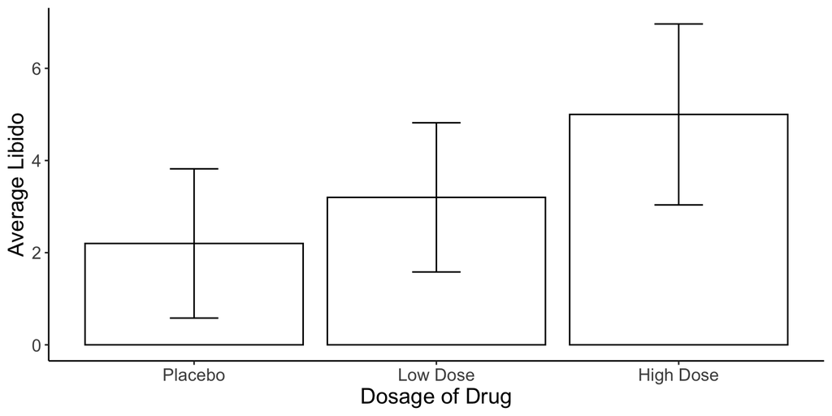

```r
library(ggplot2)

cleanup <- theme(panel.grid.major = element_blank(),
                panel.grid.minor = element_blank(),
                panel.background = element_blank(),
                axis.line.x = element_line(color = "black"),
                axis.line.y = element_line(color = "black"),
                legend.key = element_rect(fill = "white"),
                text = element_text(size = 15))

bargraph <- ggplot(master, aes(dose, libido))
bargraph +
  cleanup +
  stat_summary(fun.y = mean,
               geom = "bar",
               fill = "White",
               color = "Black") +
  stat_summary(fun.data = mean_cl_normal,
               geom = "errorbar",
               width = .2,
               position = "dodge") +
  xlab("Dosage of Drug") +
  ylab("Average Libido")
```

# Trend Analysis

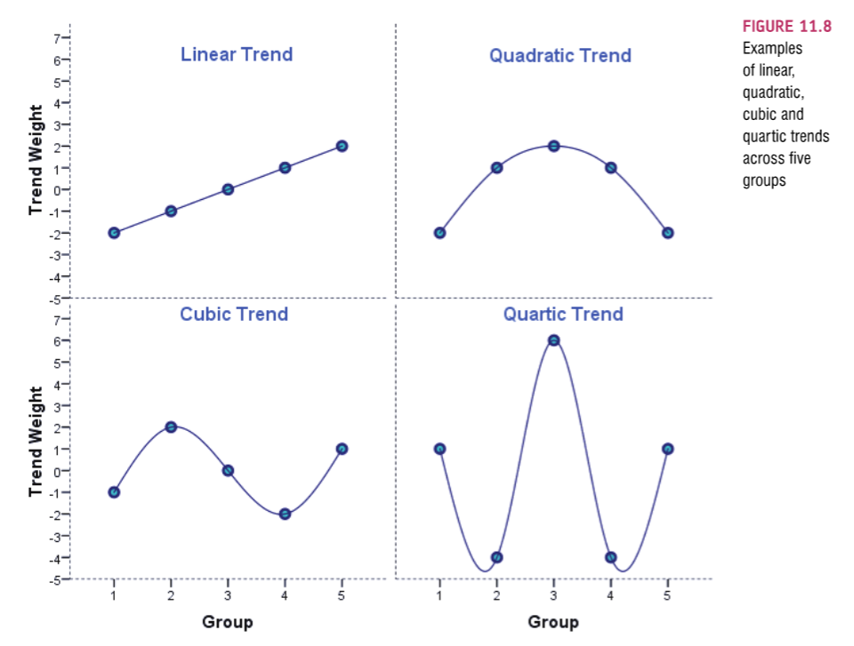

# Trend Analysis

- Quadratic Trend = a curve across levels
- Cubic Trend = two changes in direction of trend
- Quartic Trend = three changes in direction of trend
- These analyses only make sense with a somewhat “continuous” IV

# Trend Analysis

- There was a significant linear trend, $t(12) = 3.16, p = .008, R^2 = .46$, indicating that as the dose of Viagra increased, libido increased as well.

```r
## trend analysis
k = 3 ## set to the number of groups
master$dose2 <- master$dose #this changes the variable
contrasts(master$dose2) <- contr.poly(k) ## note this does change the original dataset
output <- aov(libido ~ dose2, data = master)
summary.lm(output)
```

```
##
## Call:
## aov(formula = libido ~ dose2, data = master)
##
## Residuals:
##    Min     1Q Median     3Q    Max
##   -2.0   -1.2   -0.2    0.9    2.0
##
## Coefficients:
##             Estimate Std. Error t value    Pr(>|t|)
## (Intercept)   3.4667     0.3621   9.574 0.000000572 ***
## dose2.L       1.9799     0.6272   3.157     0.00827 **
## dose2.Q       0.3266     0.6272   0.521     0.61201
## ---
## Signif. codes:  0 '***' 0.001 '**' 0.01 '*' 0.05 '.' 0.1 ' ' 1
##
## Residual standard error: 1.402 on 12 degrees of freedom
## Multiple R-squared:  0.4604, Adjusted R-squared:  0.3704
## F-statistic: 5.119 on 2 and 12 DF,  p-value: 0.02469
```

# Trend Analysis: Visualization

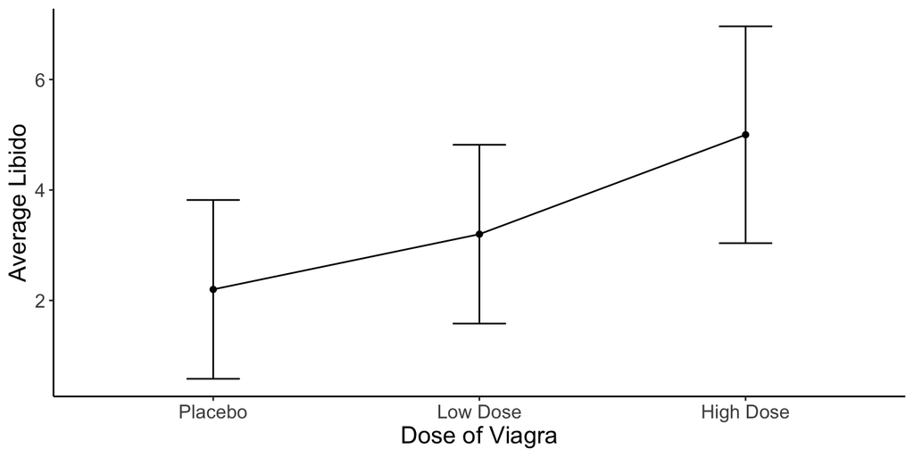

```r
doseline <- ggplot(master, aes(dose2, libido))
doseline +
  stat_summary(fun.y = mean, ## adds the points
               geom = "point") +
  stat_summary(fun.y = mean, ## adds the line
               geom = "line",
               aes(group=1)) +
  stat_summary(fun.data = mean_cl_normal, ## adds the error bars
               geom = "errorbar",
               width = .2) +
  xlab("Dose of Viagra") +
  ylab("Average Libido") +
  cleanup
```

# Power: One Way Between Subjects

- We used $f^2$ for regression, however, this analysis uses $f$.

```r
library(pwr)
eta = .46
f_eta = sqrt(eta / (1-eta))

pwr.anova.test(k = 3, #levels
               n = NULL, #leave to get sample size per group
               f = f_eta, #f from eta
               sig.level = .05, #alpha
               power = .80) #power
```

```
##
##      Balanced one-way analysis of variance power calculation
##
##               k = 3
##               n = 4.919722
##               f = 0.9229582
##       sig.level = 0.05
##           power = 0.8
##
## NOTE: n is number in each group
```

# Summary

- You made it! Here’s what we covered:
  - F statistics
  - The logic of ANOVA
  - The overall ANOVA
  - Post hoc tests
  - Trend analysis
  - Effect sizes
  - Visualizations